# IE360finalRMD

Efe Ahmet Guden

6/21/2021

#Analysis

## Importing Data

Data is imported and certain manipulations are made.

Training and test sets are created.

## Choosing the Currency

For this analysis, USD will be used for market clearing price as it is the most widely used currency in the world. Euro and Turkish Lira are excluded from the dataset.

## Visualizing the Data

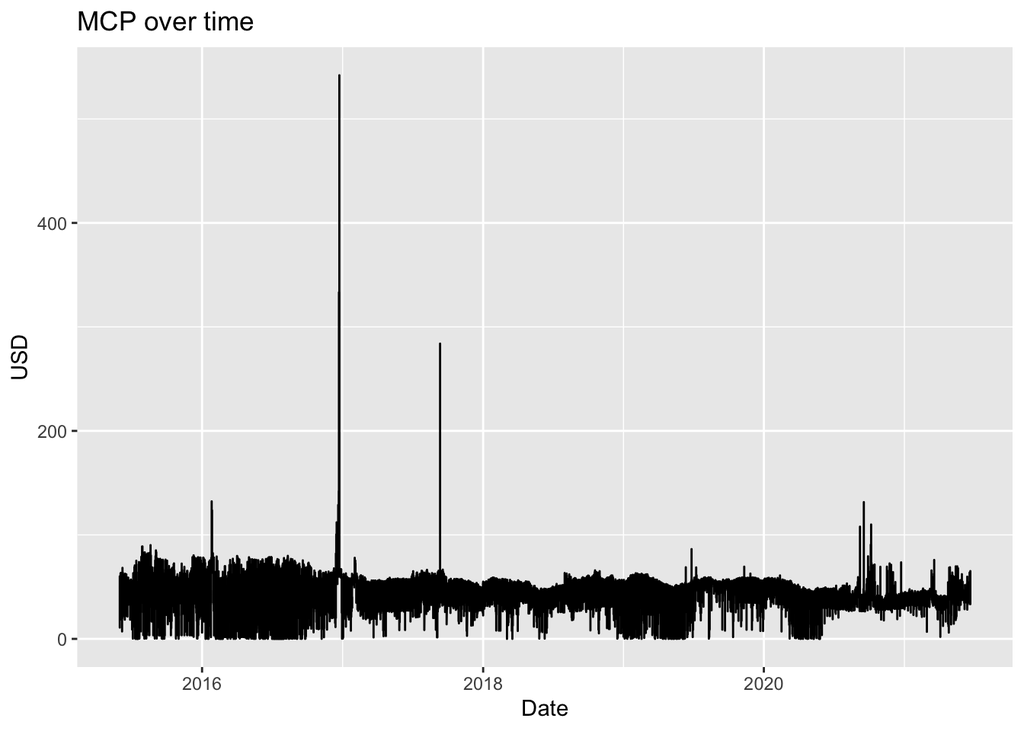

In the above plot, we observe some very high observations in 2016 December and 2017 September. This creates some difficulty in observing the overall shape of the data. Therefore, we will zoom in a three year period between 2018 and 2021.

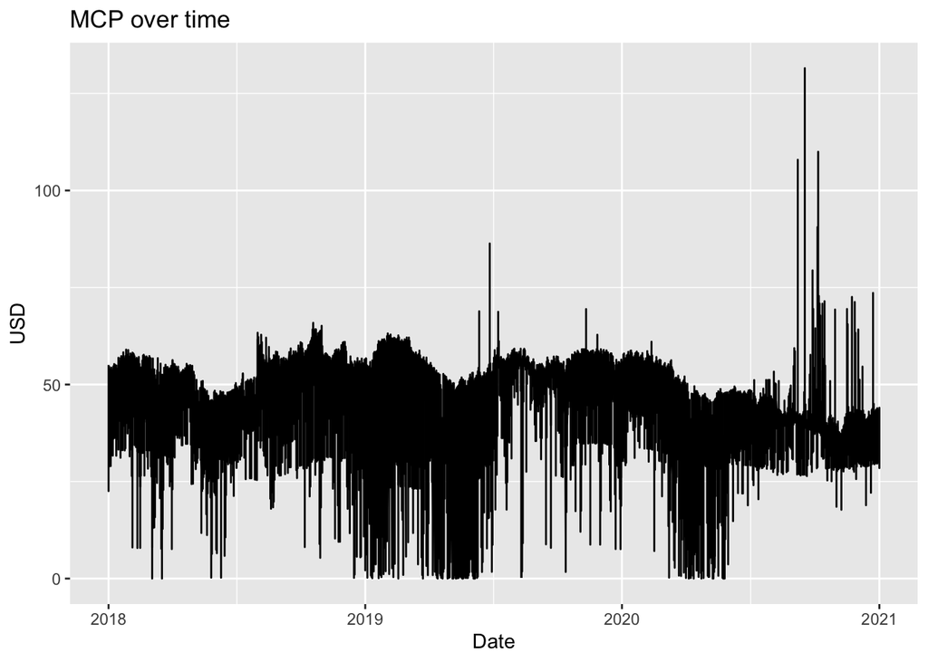

```r
summary(ur.kpss(df$mcp_dollars))
```

```
##
## #######################
## # KPSS Unit Root Test #
## #######################
##
## Test is of type: mu with 19 lags.
##
## Value of test-statistic is: 13.7123
##
## Critical value for a significance level of:
##                 10pct  5pct 2.5pct  1pct
## critical values 0.347 0.463  0.574 0.739
```

The KPSS test statistic is higher than the critical values, therefore it suggests that the data is not stationary.

## Autocorrelation Function

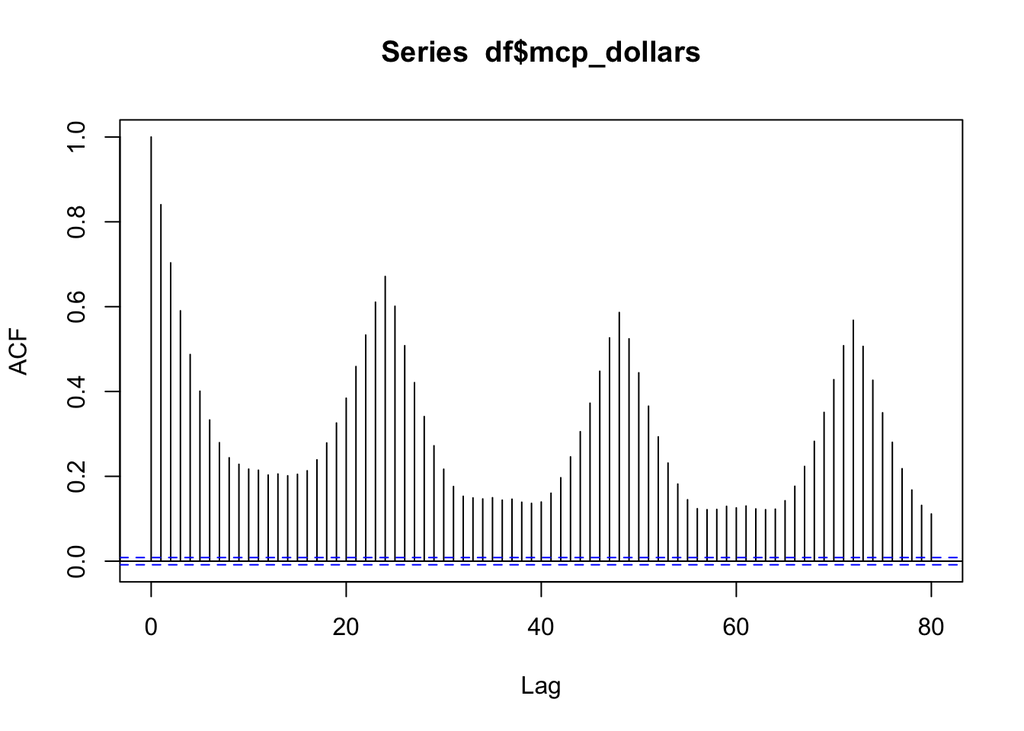

## Decomposition

We will create time series objects in order to decompose the data in hourly,daily,weekly and mothly levels in order the stationarize the data. Three plots will be analyzed: trend cycle component, seasonal component and the remaining random component. Trend cycle component explains the trend by moving average. The seasonal component is obtained when the trend cycle component is removed from the time series object. Finally, the random component is obtained when the time series object is deseasonalized and etrended. We expect this random component to be stationary. The decomposition method is selected as additive since there is no increasing trend in the variance.

### Hourly Level

The hourly decomposition plots are below.

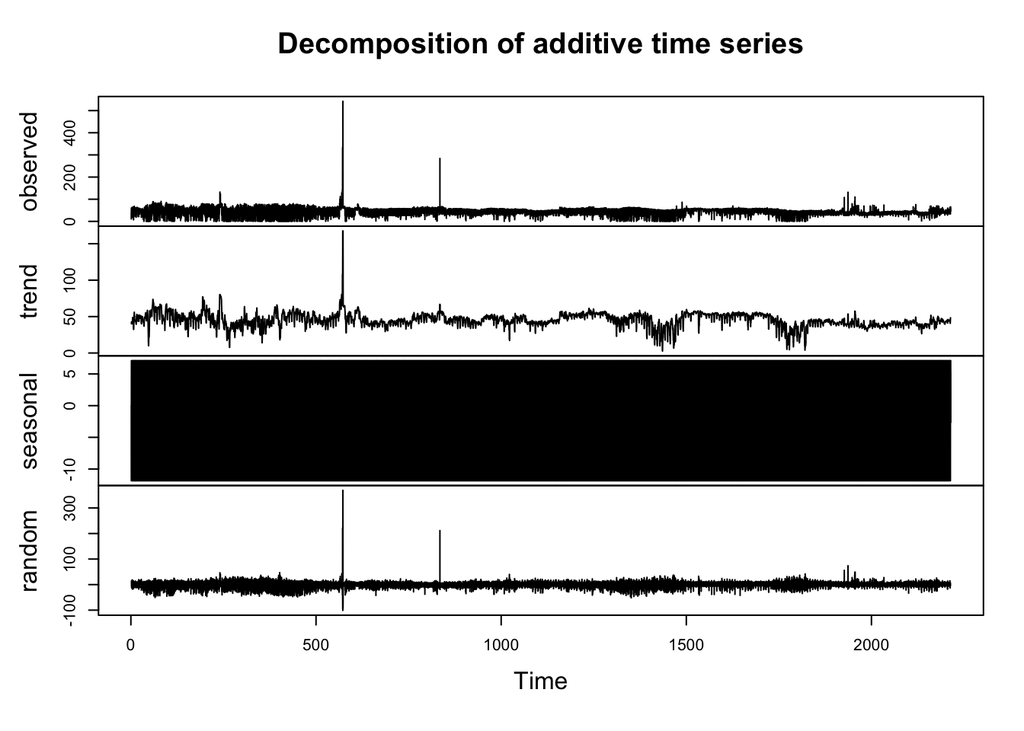

```r
plot(hourly_dec)
```

The seasonality effect on the hourly decomposition is below.

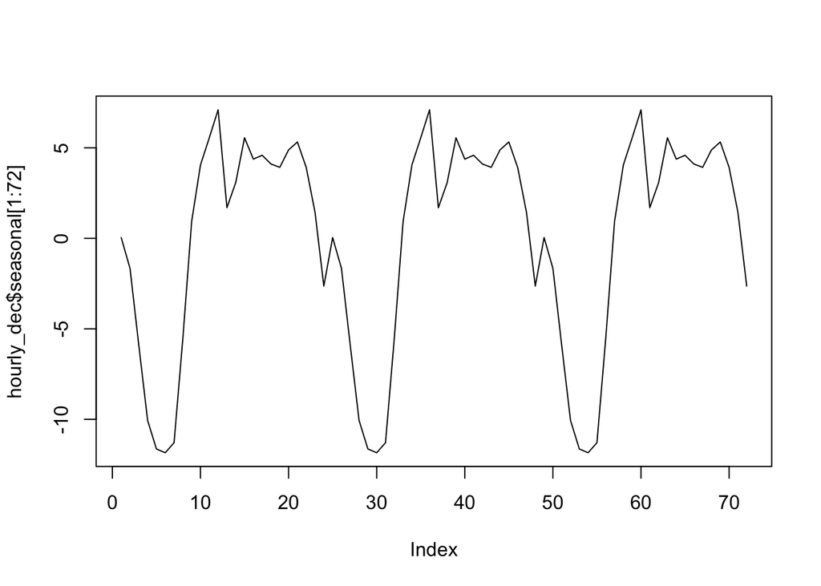

```r
plot(hourly_dec$seasonal[1:72] ,type="l")
```

### Daily Level

To analyze whether the time series follow a pattern in every 7 days or not, the time series object will be decomposed at daily level. In order to decompose the data in daily level, we should aggregate the data first.

The daily decomposition plots are below.

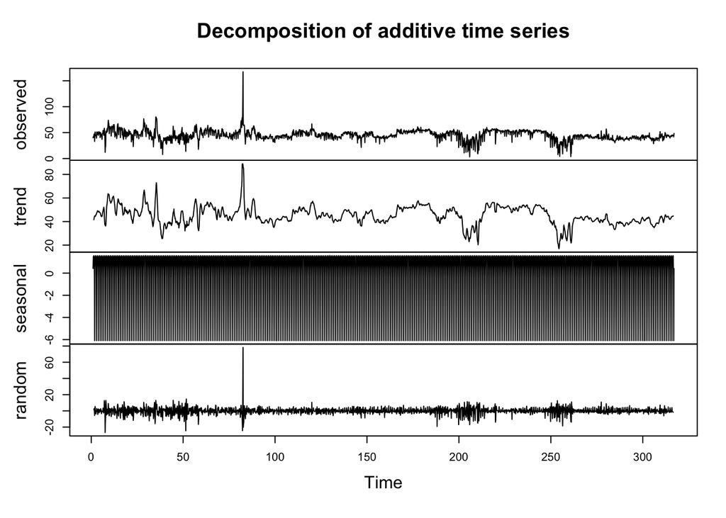

```r
plot(daily_dec)
```

The seasonality effect on the daily decomposition is below.

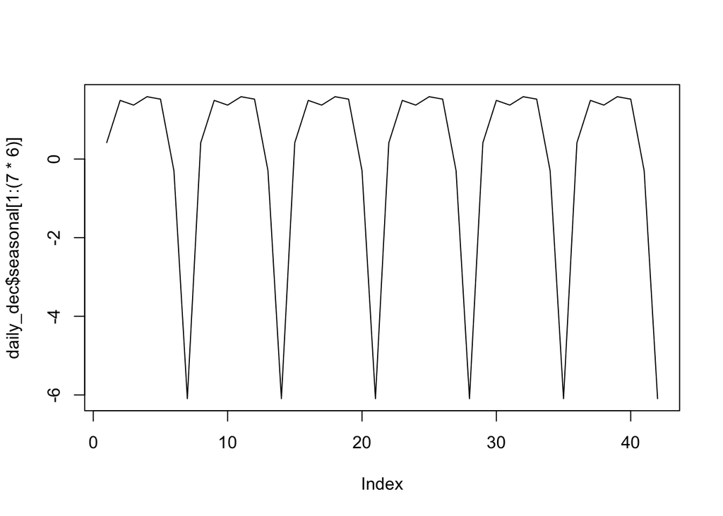

```r
plot(daily_dec$seasonal[1:(7*6)],type='l')
```

Note that 2015 June 1st is a Monday. There is an obvious effect: The price decreases in Sundays and it increases until the mid-week, then it decreases until Sundays.

The random component on the daily decomposition is below.

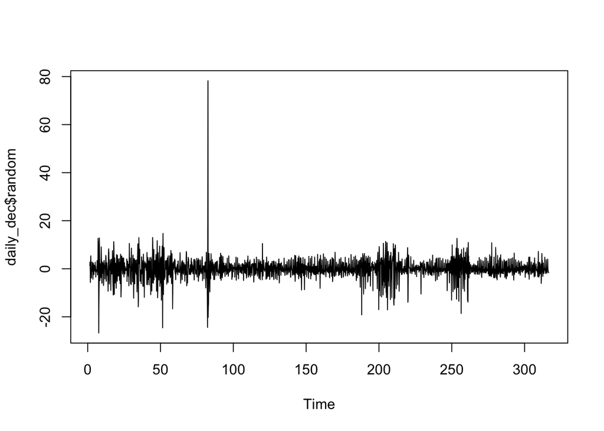

```r
plot(daily_dec$random,type='l')
```

The random component seems to be stationary. However, there are some outliers. We will zoom in to better grasp the situation.

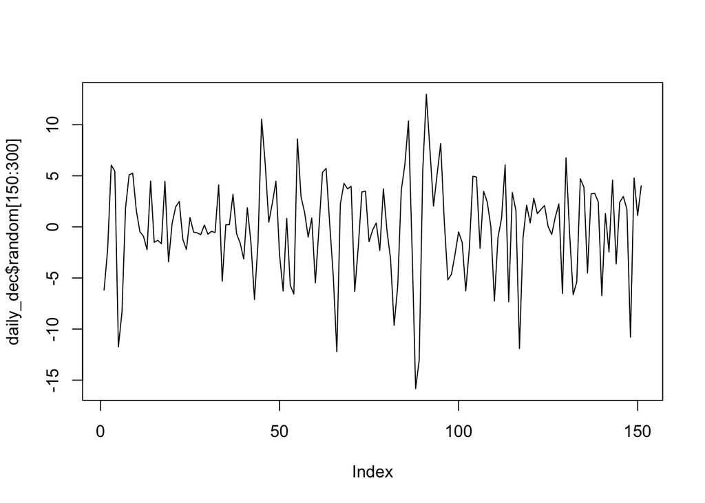

```r
plot(daily_dec$random[150:300],type='l')
```

The random component seems to be stationary. There is high variance but it it constant over time. The mean is around 0 as it should be.

### Weekly Level

To analyze whether the time series follow a pattern in every 52 weeks or not, the time series object will be decomposed at daily level. In order to decompose the data in weekly level, we should aggregate the data first.

The weekly decomposition plots are below.

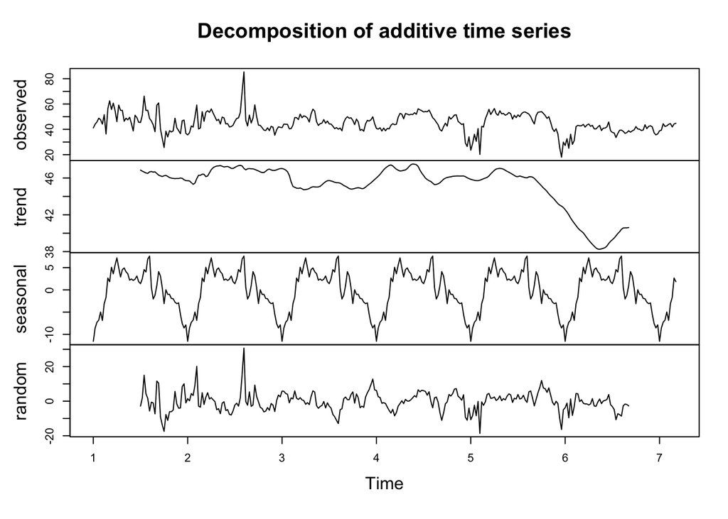

```r
plot(weekly_dec)
```

The seasonality effect on the weekly decomposition is below.

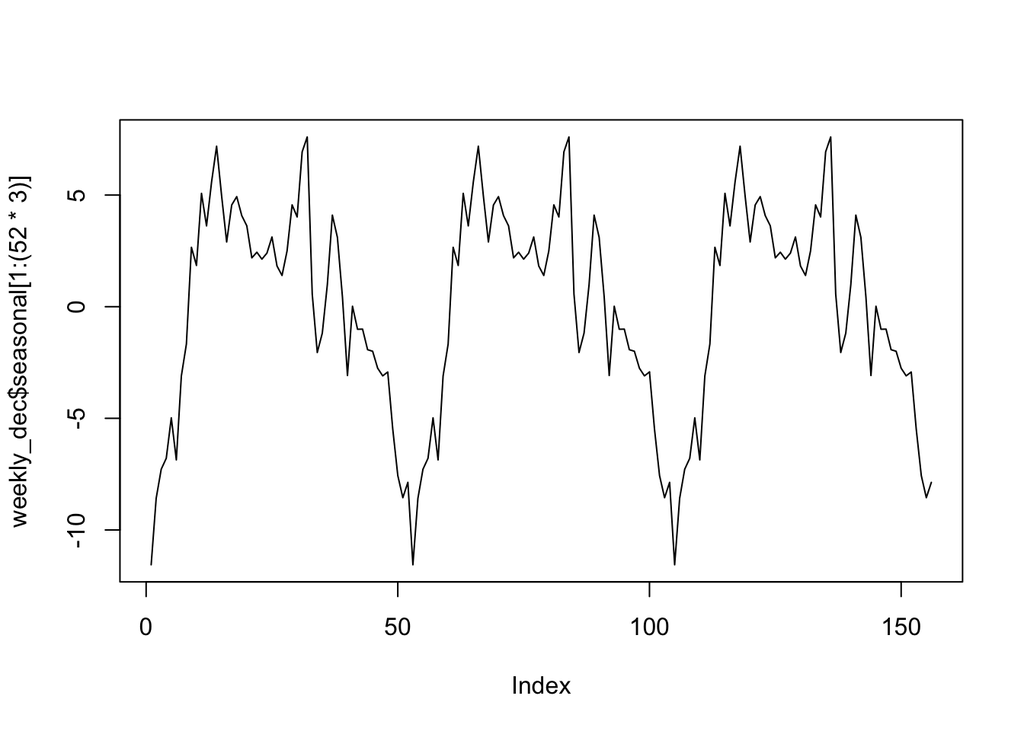

```r
plot(weekly_dec$seasonal[1:(52*3)], type="l")
```

There is a complex seasonal effect. Therefore weekly decomposition will not be used in this analysis.

### Monthly Level

To analyze whether the time series follow a pattern in every 12 months or not, the time series object will be decomposed at daily level. In order to decompose the data in weekly level, we should aggregate the data first.

The monthly decomposition plots are below.

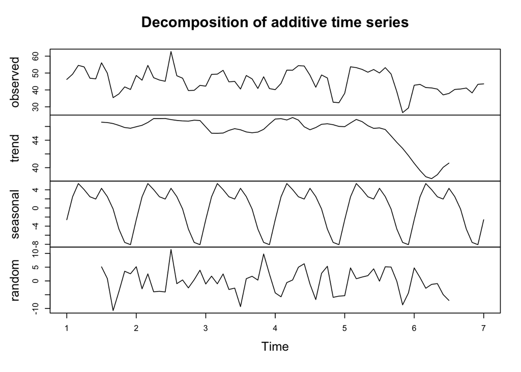

```r
plot(monthly_dec)
```

The random component seems to be stationary. Also the seasonal effect can be observed. The price is at the lowest point in the month of May. The price is high in winters and summers.

## Chosen Level is the Daily Level

The chosen level is the daily level. From now on we will build a model on daily decomposed time series object.

The random component of the daily decomposed time series object is below.

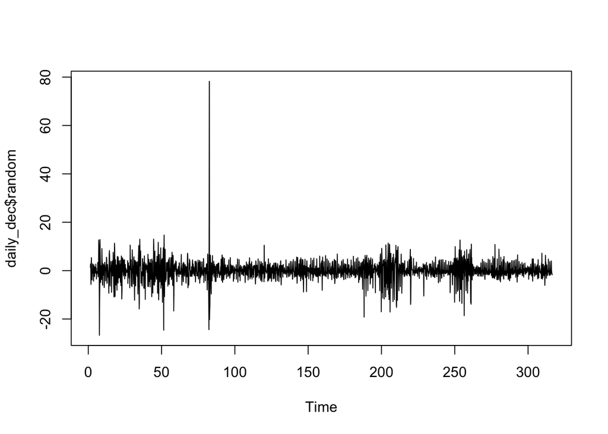

```r
plot(daily_dec$random)
```

It seems to be stationary. Now lets test this with the KPSS test.

```r
summary(ur.kpss(daily_dec$random))
```

```
##
## #######################
## # KPSS Unit Root Test #
## #######################
##
## Test is of type: mu with 8 lags.
##
## Value of test-statistic is: 0.0027
##
## Critical value for a significance level of:
##                 10pct  5pct 2.5pct  1pct
## critical values 0.347 0.463  0.574 0.739
```

H0 in KPSS test states that the data is stationary. The value of test statistic is significantly lower than all the critical values. The outcome declares that there is no evidence to reject the idea of the price over time being stationary. Therefore we can state that the random component is stationary.

Now lets analyze the ACF and PACF of the random component.

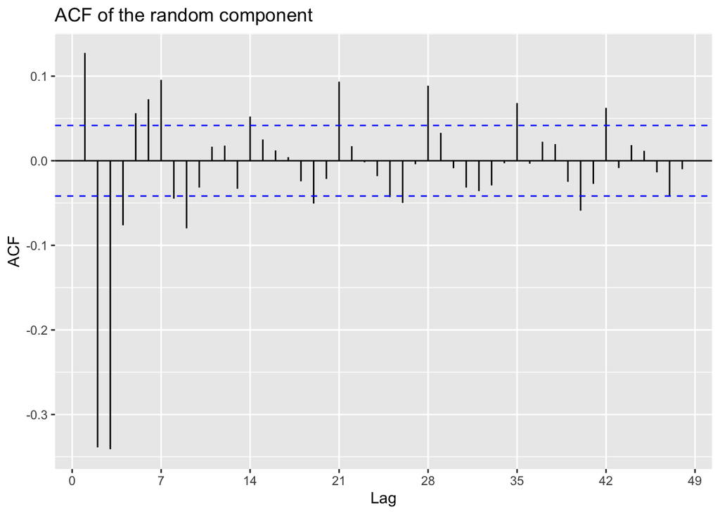

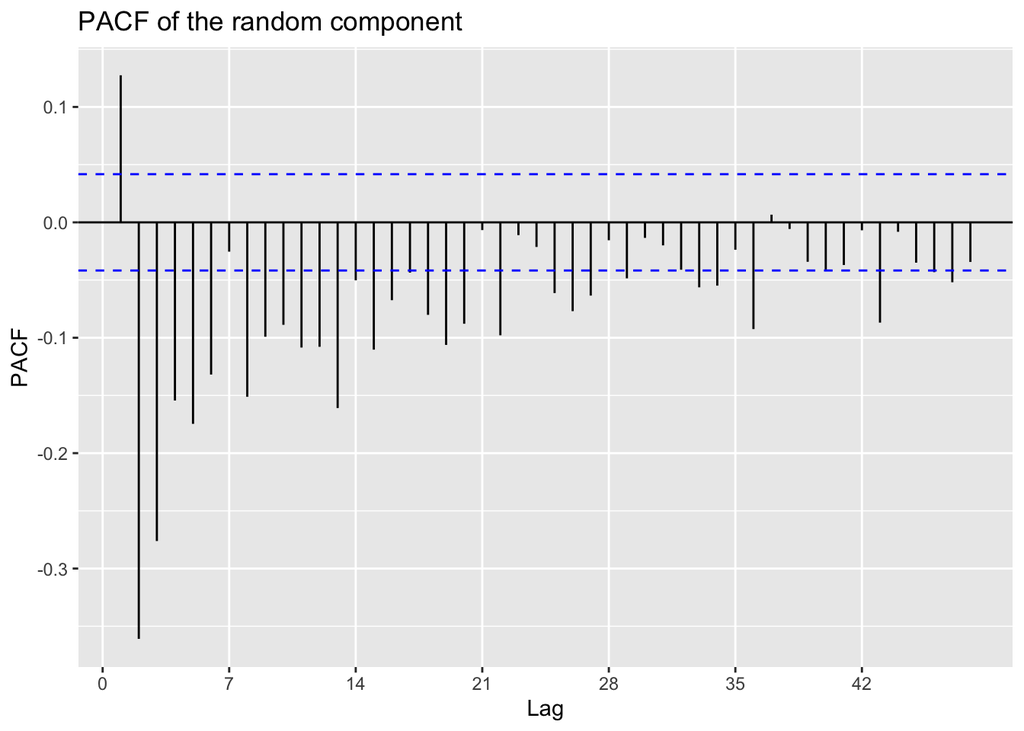

ACF: There are negative significant spikes at lag 2 and lag 3. Also there is a significant spike at lag 1. There is a decreasing trend in the ACF.

PACF: There is a significant spike at lag 1. Then there are negative significant spikes. There is also a decaying trend in the PACF.

## Creating a SARIMA model

We will fit a SARIMA model on the random component of the daily decomposed series. We will benefit from the auto.arima() function since there is limited time, and hope it gives a good model.

```
## [1] 12135.54
```

## Regression Model

We will fit several linear regression models and select the best one among them.

Weekdays, month, quarter effect will be tried. Also a trend variable is added to the data.

### Model 1

Effects of trend, load plan and seasonality effects of weekdays will be added to the model

```r
summary(model1)
```

```
##
## Call:
## lm(formula = mcp_dollars ~ load_plan + Weekday + Trend, data = df)
##
## Residuals:
##    Min     1Q Median     3Q    Max
## -50.09  -6.17   0.33   6.86 480.82
##
## Coefficients:
##               Estimate Std. Error t value Pr(>|t|)
## (Intercept)  1.493e+00  3.655e-01   4.084 4.44e-05 ***
## load_plan    1.530e-03  1.014e-05 150.853  < 2e-16 ***
## Weekday      6.750e-02  2.626e-02   2.571   0.0102 *
## Trend       -2.452e-04  3.415e-06 -71.819  < 2e-16 ***
## ---
## Signif. codes:  0 '***' 0.001 '**' 0.01 '*' 0.05 '.' 0.1 ' ' 1
##
## Residual standard error: 11.8 on 53108 degrees of freedom
## Multiple R-squared:  0.3243, Adjusted R-squared:  0.3242
## F-statistic:  8495 on 3 and 53108 DF,  p-value: < 2.2e-16
```

Load plan and trend has significant effects. Adj R squared is 0.32. The model has to be improved.

### Model 2

Excess = Total Production - Load Plan Renewable Ratio is calculated. This is the ratio of renewable energy production to the total energy procution.

```r
df$renewable <- df$wind + df$geothermal + df$biomass + df$river + df$dam
df$ren_ratio <- df$renewable/df$total_prod
df$excess <- df$total_prod-df$load_plan
```

The effect of excess production and the renewable ratio will be added. Excess production may be an important factor in market clearing prices. If the production is well above the consumption the prices will be low and vice versa. Also renewable energy is cheaper to produce. Thus, if the renewable ratio increases, the market clearing prices will be lower.

```r
summary(model2)
```

```
##
## Call:
## lm(formula = mcp_dollars ~ excess + ren_ratio + Weekday + Trend,
##     data = df)
##
## Residuals:
##    Min     1Q Median     3Q    Max
## -56.00  -6.98   0.70   9.34 495.53
##
## Coefficients:
##               Estimate Std. Error t value Pr(>|t|)
## (Intercept)  5.323e+01  2.572e-01  206.98   <2e-16 ***
## excess      -7.898e-04  3.026e-05  -26.10   <2e-16 ***
## ren_ratio   -1.624e+01  5.172e-01  -31.40   <2e-16 ***
## Weekday     -7.570e-01  3.014e-02  -25.12   <2e-16 ***
## Trend       -6.837e-05  4.274e-06  -16.00   <2e-16 ***
## ---
## Signif. codes:  0 '***' 0.001 '**' 0.01 '*' 0.05 '.' 0.1 ' ' 1
##
## Residual standard error: 13.86 on 53107 degrees of freedom
## Multiple R-squared:  0.06742,    Adjusted R-squared:  0.06735
## F-statistic: 959.9 on 4 and 53107 DF,  p-value: < 2.2e-16
```

The new predictors are significant, however the adj R squred is still too low.

### Model 3

Now, variables at lag 1 and lag 24 will be added to the model.

```r
df[,lag1:=shift(mcp_dollars,1)]
df[,lag24:=shift(mcp_dollars,24)]
```

Trend predictor will be removed since we added the variable at lag 1.

```r
summary(model3)
```

```
##
## Call:
## lm(formula = mcp_dollars ~ excess + ren_ratio + Weekday + lag24 +
##     lag1, data = df)
##
## Residuals:
##     Min      1Q  Median      3Q     Max
## -139.40   -2.39    0.21    2.40  349.62
##
## Coefficients:
##               Estimate Std. Error t value Pr(>|t|)
## (Intercept)  5.470e+00  1.778e-01  30.772  < 2e-16 ***
## excess      -8.776e-05  1.565e-05  -5.608 2.06e-08 ***
## ren_ratio   -2.293e+00  2.537e-01  -9.035  < 2e-16 ***
## Weekday     -4.593e-01  1.605e-02 -28.610  < 2e-16 ***
## lag24        2.665e-01  2.814e-03  94.716  < 2e-16 ***
## lag1         6.647e-01  2.824e-03 235.379  < 2e-16 ***
## ---
## Signif. codes:  0 '***' 0.001 '**' 0.01 '*' 0.05 '.' 0.1 ' ' 1
##
## Residual standard error: 7.168 on 53082 degrees of freedom
##   (24 observations deleted due to missingness)
## Multiple R-squared:  0.7507, Adjusted R-squared:  0.7507
## F-statistic: 3.197e+04 on 5 and 53082 DF,  p-value: < 2.2e-16
```

The adjusted R squared is now 0.75. All predictors are significant. The F-statistic’s p-value is significantly small, hence we can state that the model is reasonable. We will use this model to do our forecasts.

## Regression Model Analysis

The overall performance and the residuals are going to be analyzed in this section. Firstly, the residuals are going to be observed.

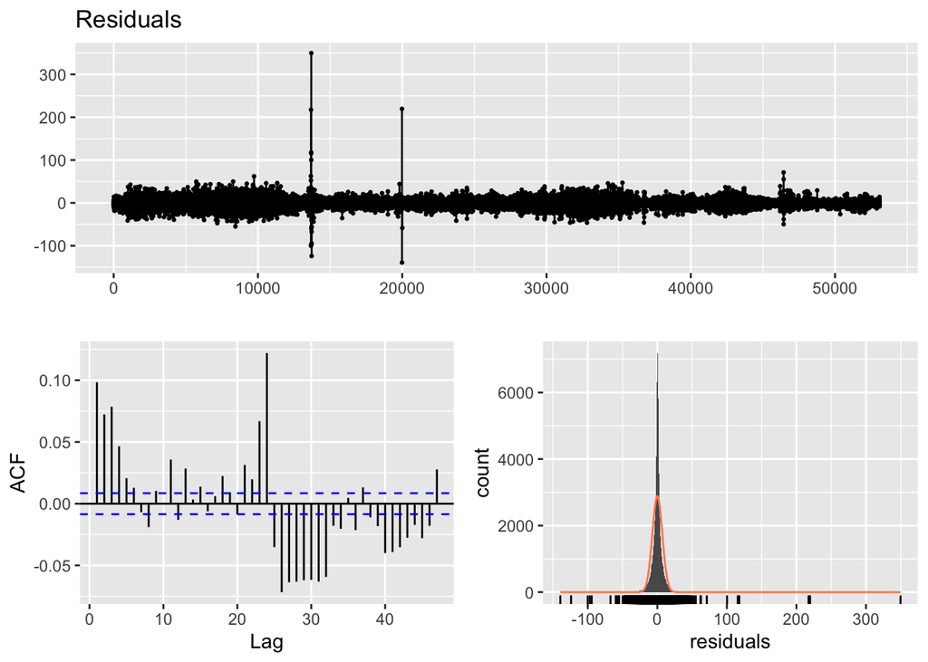

```
##
##  Breusch-Godfrey test for serial correlation of order up to 10
##
## data:  Residuals
## LM test = 3212.9, df = 10, p-value < 2.2e-16
```

```r
checkresiduals(model3)
```

Fitted vs actual graph is below:

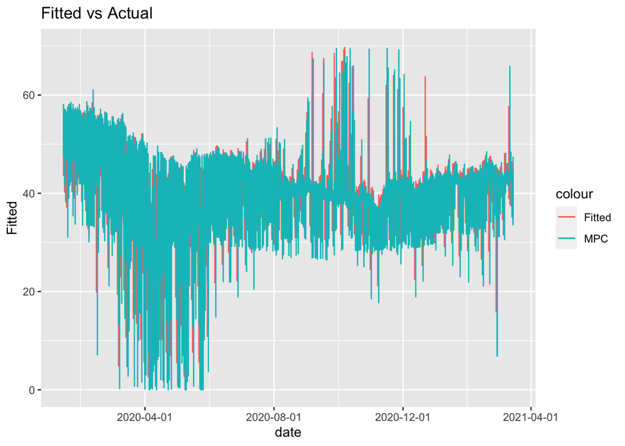

The model seems to predict the fitted values.

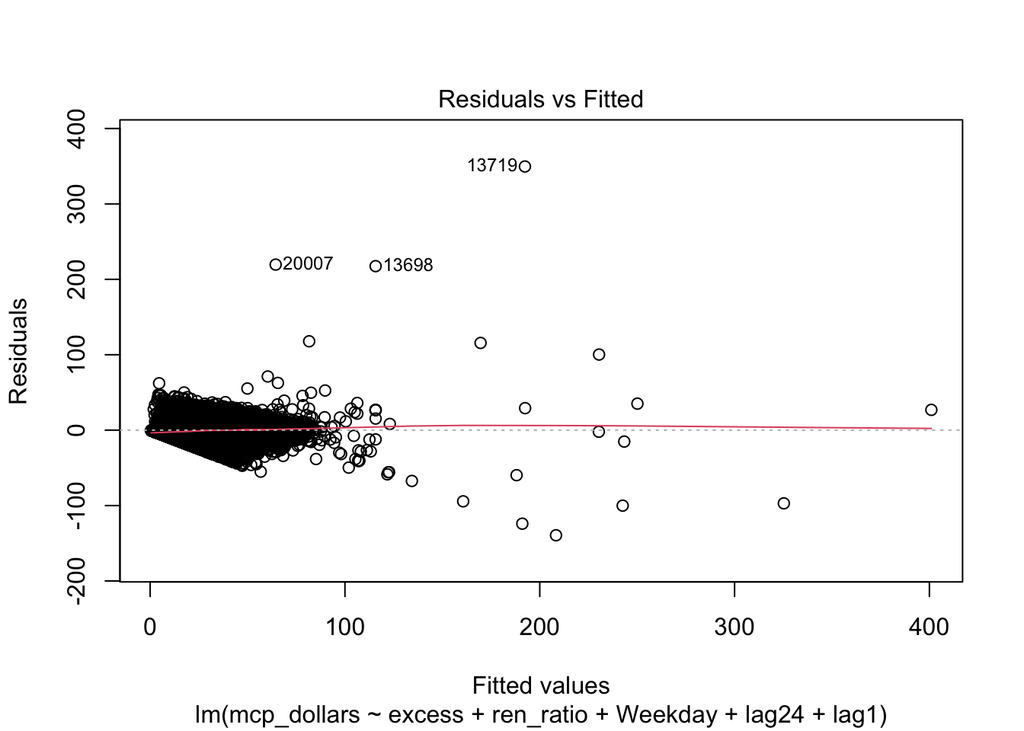

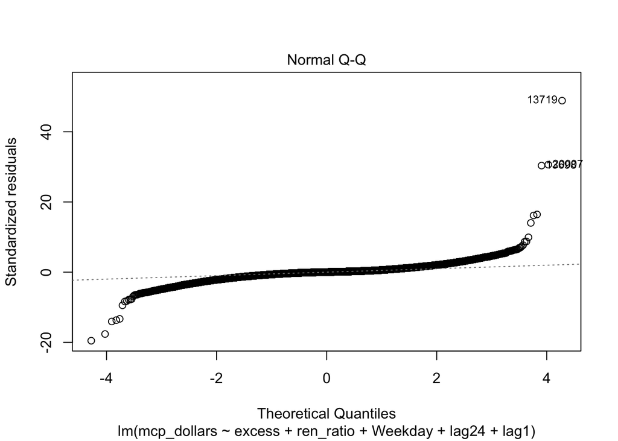

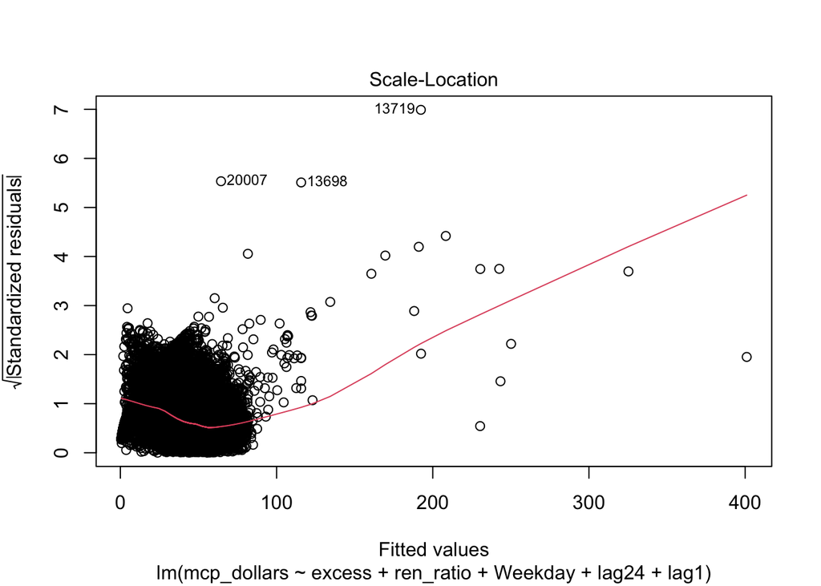

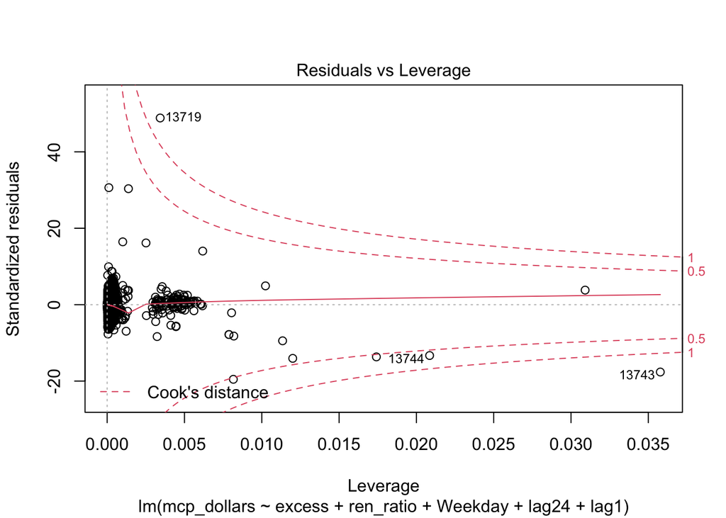

## Regression Model Forecasts

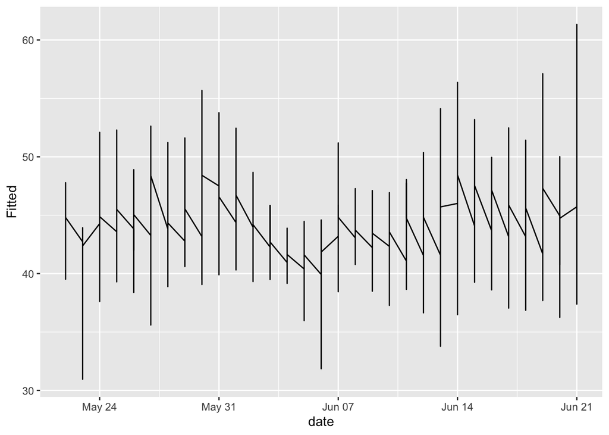

# Conclusion

Forecasts with the SARIMA model could not be made due to time constraints. Yet the SARIMA model should be better at forecasting since the linear model has an adj R squared of 0.75. Also SARIMA models use lagged resiudals as well as lagged variables. It is a more advanced method as compared to the linear regression approach. SARIMA model forecasts will be closer to actual values in the test set.